# Introduction to Linear Regression

```r
mlb <- read.csv("https://anna-neufeld.github.io/Stat311/oiLabs/Week10/mlb11.csv")
```

1. Use `geom_point()` to make a plot that explores the relationship between `runs` and `at_bats`. Does the relationship look linear?

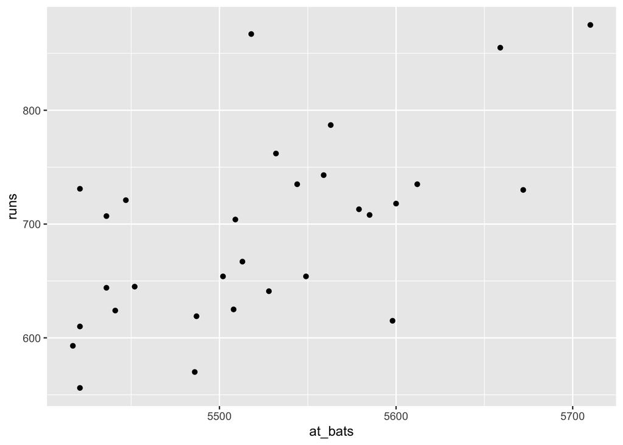

```r
ggplot(data=mlb, aes(x=at_bats, y=runs)) + geom_point()
```

**There seems to be a weak linear relationship between the variables.**

1. Describe the relationship between the two variables plotted above. Mention the form, direction, and strength of the relationship as well as any unusual observations.

**There is a positive, weak relationship between the variables. The shape of the relationship seems roughly linear, although it is hard to say if there might be a better “shape”. There are not any particularly unusual points, although one of the teams with an extremely large number of runs (over 850) also had relatively new at bats (only around 5500).** 1.

```r
mlb %>% summarise(cor(runs, homeruns))
```

```
##   cor(runs, homeruns)
## 1           0.7915577
```

1. Run `plot_ss` several times. Choose the line that does the best job of minimizing the sum of squares. What slope and intercept corresponded to this “best” line? **Everyone will have slightly different answers. For example, a line with an intercept of -5450 and a slope of 1.112 looks pretty reasonable but gives a sum of squares of 167000. The line with intercept -3414 and slope 0.75 is slightly better; SSE is 148846. The line with intercept -4264 and slope 0.8994 had a slower SSE of 139419. Any reported slope and intercept in this ballpartk is ok.**.
2. The Seattle Mariners had 5421 at bats in 2011. Suppose that you had access to the regression line but not the actual data. How many runs would you predict that the Mariners would score in 2011?

```r
model <- lm(runs~at_bats, data=mlb)
intercept <- model$coefficients[1]
slope <- model$coefficients[2]
intercept + slope*5421
```

```
## (Intercept)
##    628.9686
```

**We would predict 628.96 runs**.

1. Was your answer to the previous exercise an underestimate or an overestimate? In order to explain your answer, use the regression line to calculate the **residual**.

```r
mlb %>% filter(team=="Seattle Mariners")%>% select(runs)
```

```
##   runs
## 1  556
```

```r
629.96-556
```

```
## [1] 73.96
```

```r
summary(lm(runs~homeruns, data=mlb))
```

```
##
## Call:
## lm(formula = runs ~ homeruns, data = mlb)
##
## Residuals:
##     Min      1Q  Median      3Q     Max
## -91.615 -33.410   3.231  24.292 104.631
##
## Coefficients:
##             Estimate Std. Error t value Pr(>|t|)
## (Intercept) 415.2389    41.6779   9.963 1.04e-10 ***
## homeruns      1.8345     0.2677   6.854 1.90e-07 ***
## ---
## Signif. codes:  0 '***' 0.001 '**' 0.01 '*' 0.05 '.' 0.1 ' ' 1
##
## Residual standard error: 51.29 on 28 degrees of freedom
## Multiple R-squared:  0.6266, Adjusted R-squared:  0.6132
## F-statistic: 46.98 on 1 and 28 DF,  p-value: 1.9e-07
```

1. What proportion of variability in `runs` is explained by variation in `homeruns`?

```r
summary(lm(runs~homeruns, data=mlb))$r.squared
```

```
## [1] 0.6265636
```

**Read the $R^2$ value from the table above. 62.66% of variability in runs is explained by variability in homeruns.**

1. Which of the following variables seems to best predict `runs`? You may use $R^2$ as your criteria
   - `stolen_bases`
   - `new_obs`
   - `new_slug`
   - `homeruns`

   **The correct answer is new_obs. Fine if you didn’t show work here (assuming you explored the models in your console), because printing out all four summary objects is a lot of text. I have printed out just the four $R^2$ values below.**

```r
summary(lm(runs~stolen_bases, data=mlb))$r.squared
```

```
## [1] 0.002913993
```

```r
summary(lm(runs~new_obs, data=mlb))$r.squared
```

```
## [1] 0.9349271
```

```r
summary(lm(runs~new_slug, data=mlb))$r.squared
```

```
## [1] 0.8968704
```

```r
summary(lm(runs~homeruns, data=mlb))$r.squared
```

```
## [1] 0.6265636
```

1. Show appropriate visual and numerical summaries of the model that you chose in the previous exercise.

**It would be nice to (at a minimum) print the summary output and show a scatterplot for the new_obs variable.**

```r
summary(lm(runs~new_obs, data=mlb))
```

```
##
## Call:
## lm(formula = runs ~ new_obs, data = mlb)
##
## Residuals:
##     Min      1Q  Median      3Q     Max
## -43.456 -13.690   1.165  13.935  41.156
##
## Coefficients:
##             Estimate Std. Error t value Pr(>|t|)
## (Intercept)  -686.61      68.93  -9.962 1.05e-10 ***
## new_obs      1919.36      95.70  20.057  < 2e-16 ***
## ---
## Signif. codes:  0 '***' 0.001 '**' 0.01 '*' 0.05 '.' 0.1 ' ' 1
##
## Residual standard error: 21.41 on 28 degrees of freedom
## Multiple R-squared:  0.9349, Adjusted R-squared:  0.9326
## F-statistic: 402.3 on 1 and 28 DF,  p-value: < 2.2e-16
```

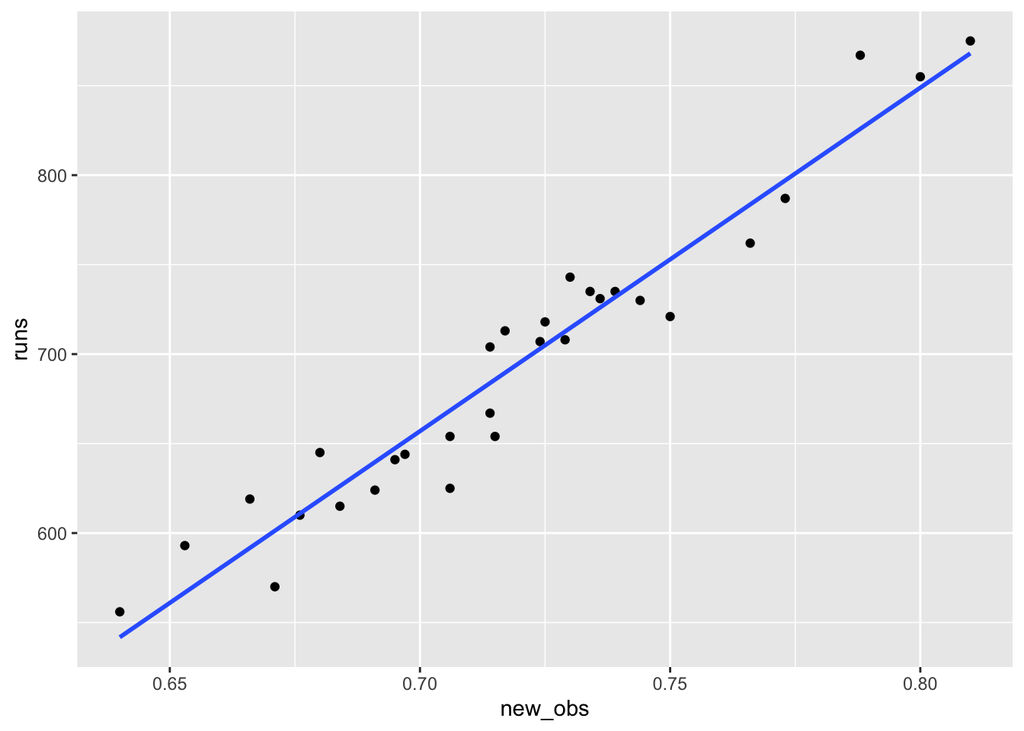

```r
ggplot(data=mlb, aes(x=new_obs, y=runs)) + geom_point() + stat_smooth(method="lm", se=FALSE)
```

1. Which of the following variables had a **negative** relationship with `runs`? Does this make sense?
   - `wins`
   - `strikeouts`
   - `bat_avg`
   - `hits`

**I have printed the four slopes below**

```r
(lm(runs~wins, data=mlb))$coeff[2]
```

```
##     wins
## 4.341028
```

```r
(lm(runs~strikeouts, data=mlb))$coeff[2]
```

```
## strikeouts
##  -0.314139
```

```r
(lm(runs~bat_avg, data=mlb))$coeff[2]
```

```
##  bat_avg
## 5242.229
```

```r
(lm(runs~hits, data=mlb))$coeff[2]
```

```
##      hits
## 0.7588615
```

**Only strikeouts is negative. This makes sense. Strikeouts are a “bad” thing for a team; more strikeouts should be associated with less total runs.**

1. Show appropriate visual and numerical summaries of the model that you chose in the previous exercise.

```r
summary(lm(runs~strikeouts, data=mlb))
```

```
##
## Call:
## lm(formula = runs ~ strikeouts, data = mlb)
##
## Residuals:
##     Min      1Q  Median      3Q     Max
## -132.27  -46.95  -11.92   55.14  169.76
##
## Coefficients:
##              Estimate Std. Error t value Pr(>|t|)
## (Intercept) 1054.7342   151.7890   6.949 1.49e-07 ***
## strikeouts    -0.3141     0.1315  -2.389   0.0239 *
## ---
## Signif. codes:  0 '***' 0.001 '**' 0.01 '*' 0.05 '.' 0.1 ' ' 1
##
## Residual standard error: 76.5 on 28 degrees of freedom
## Multiple R-squared:  0.1694, Adjusted R-squared:  0.1397
## F-statistic: 5.709 on 1 and 28 DF,  p-value: 0.02386
```

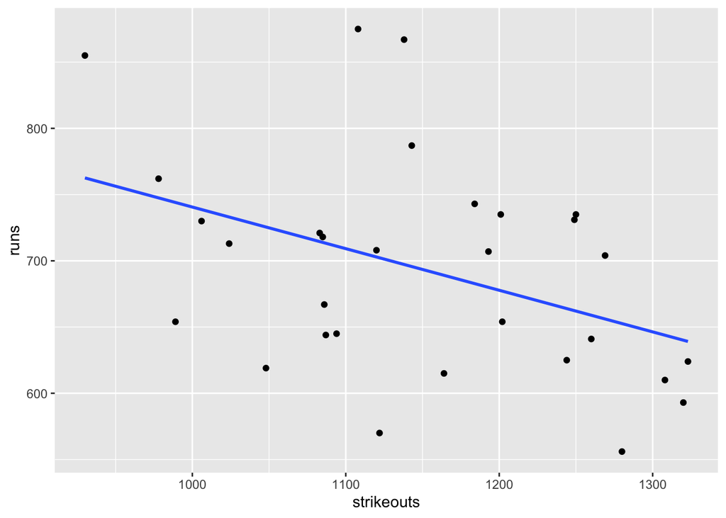

```r
ggplot(data=mlb, aes(x=strikeouts, y=runs)) + geom_point() + stat_smooth(method="lm", se=FALSE)
```